# Análise Exploratória de Dados da Educação Superior em R

Bibliotecas utilizadas:

```r
library(readxl)
library(readr)
library(dplyr)
library(tidyr)
library(ggplot2)
```

Localização dos dados:

```r
dicionario_dados <- read_excel("/microdados_censo_da_educacao_superior_2024/dicionario_dados_educacao_superior.xlsx")
dados_cursos <- read.csv("/microdados_censo_da_educacao_superior_2024/MICRODADOS_CADASTRO_CURSOS_2024.CSV", sep=';', encoding='latin1')
```

## 3.3 Em relação aos cursos

Montagem do banco de dados que será utilizado nessas análizes:

```r
dadosA <- data.frame(
  "Curso" = dados_cursos$NO_CINE_ROTULO,
  "Tipo_de_curso"= case_when(
      dados_cursos$TP_GRAU_ACADEMICO == 1 ~ "Bacharelado",
      dados_cursos$TP_GRAU_ACADEMICO == 2 ~ "Licenciatura",
      dados_cursos$TP_GRAU_ACADEMICO == 3 ~ "Tecnólogo",
      dados_cursos$TP_GRAU_ACADEMICO == 4 ~ "Bacharelado e Licenciatura",
      TRUE ~ "Não se aplica"
    ),
  "Quantidade_de_vagas"= dados_cursos$QT_VG_TOTAL,
  "Numero_de_ingressantes"=dados_cursos$QT_ING,
  "Numero_de_concluintes"=dados_cursos$QT_CONC
  )
```

Vamos analisar quais são os 10 cursos que são oferecidos em maior quantidade, para isso fazemos um código que contabiliza quantas vezes cada curso é oferecido, organiza os cursos em ordem decrescente de quantidade e separa os 10 mais oferecidos:

```r
dadosA_frequentes <- dadosA %>%
  group_by(Curso) %>%
summarise(
  Quantidade_de_cursos = n(),.groups = 'drop') %>%
  mutate(Total_Geral = sum(Quantidade_de_cursos),`Percentual (%)` = round((Quantidade_de_cursos / Total_Geral) * 100, 2)
  ) %>%
  select(-Total_Geral)

ord_dadosA <- dadosA_frequentes %>%
  arrange(desc(Quantidade_de_cursos))%>%
slice_head(n = 10)
print(ord_dadosA)
```

```
## # A tibble: 10 × 3
##    Curso                  Quantidade_de_cursos `Percentual (%)`
##    <chr>                                 <int>            <dbl>
##  1 Pedagogia                             21063             2.92
##  2 Sistemas de informação                20334             2.82
##  3 Administração                         19205             2.67
##  4 Marketing                             18088             2.51
##  5 Gestão de pessoas                     16920             2.35
##  6 Contabilidade                         16119             2.24
##  7 Gestão financeira                     13518             1.88
##  8 Gestão de negócios                    12442             1.73
##  9 Gestão comercial                      11807             1.64
## 10 Serviço social                        11801             1.64
```

É possivel perceber que 7 dos 10 cursos mais oferecidos tem relação com a área empresarial.

Ao análisarmos os tipos de graduação, o tecnólogo é consideravelmente mais oferecido do que os outros tipos, chegando a ser quase que metade dos cursos. Uma maior quantidade de cursos da área empresarial e de cursos tecnólogos podem refletir uma demanda para uma formação mais rápida e direcionada para o ingresso no mercado de trabalho.

```r
tipo_curso <- dadosA %>%
 group_by(Tipo_de_curso) %>%
 summarise(
   Quant_grau =n(),.groups = 'drop') %>%
  mutate(Total_tipo = sum(Quant_grau),`Percentual (%)` = round((Quant_grau / Total_tipo) *100, 2)
 ) %>%
  select(-Total_tipo,-Quant_grau)

ord_tipo <- tipo_curso %>%
  arrange(desc(`Percentual (%)`))
print(ord_tipo)
```

```
## # A tibble: 4 × 2
##   Tipo_de_curso `Percentual (%)`
##   <chr>                    <dbl>
## 1 Tecnólogo                47
## 2 Bacharelado              33.8
## 3 Licenciatura             19.0
## 4 Não se aplica             0.28
```

```r
vagasA<- dadosA %>%
  group_by(Tipo_de_curso) %>%
  summarise(
    vagas_total = sum(Quantidade_de_vagas),
    ingressantes= sum(Numero_de_ingressantes),
    `%_vagas_preenchidas`= round((ingressantes/vagas_total) *100,2),
    concluintes= sum(Numero_de_concluintes),
    `%_de_concluintes`= round((concluintes/ingressantes) *100,2),
    .groups = 'drop')%>%
  arrange(desc(`%_vagas_preenchidas`))
print(vagasA)
```

```
## # A tibble: 4 × 6
##   Tipo_de_curso vagas_total ingressantes `%_vagas_preenchidas` concluintes
##   <chr>               <int>        <int>                 <dbl>       <int>
## 1 Não se aplica       89808        44601                  49.7         160
## 2 Bacharelado      10052829      2716664                  27.0      771706
## 3 Licenciatura      4255957       804048                  18.9      205697
## 4 Tecnólogo         9266825      1445300                  15.6      356425
## # ℹ 1 more variable: `%_de_concluintes` <dbl>
```

## 3.4 Preenchimento de vagas ofertadas por região

Montando um banco de dados para essa análise:

```r
dadosB <-data.frame(
  "regiao"= case_when(
    dados_cursos$NO_REGIAO==""~"Remoto",
    dados_cursos$NO_REGIAO=="Centro-Oeste"~"Centro-Oeste",
    dados_cursos$NO_REGIAO=="Nordeste"~"Nordeste",
    dados_cursos$NO_REGIAO=="Norte"~"Norte",
    dados_cursos$NO_REGIAO=="Sudeste"~"Sudeste",
    dados_cursos$NO_REGIAO=="Sul"~"Sul"),
  "qnt_vagas"= dados_cursos$QT_VG_TOTAL,
  "qnt_ingressantes"=dados_cursos$QT_ING,
  "tipo_de_inst"= case_when(
    dados_cursos$TP_REDE=="1"~"Publica",
    dados_cursos$TP_REDE=="2"~"Privada"),
  "nmr_concluintes"=dados_cursos$QT_CONC
)
```

```r
vagas_regiao<- dadosB %>%
  group_by(regiao) %>%
  summarise(
    vagas_total= sum(qnt_vagas),
    ingressantes= sum(qnt_ingressantes),
    `%_de_preenchimento`= round((ingressantes/vagas_total)*100,2),
    .groups = 'drop')

ord_vagas_regiao<- vagas_regiao%>%
  arrange(desc(`%_de_preenchimento`))
print(ord_vagas_regiao)
```

```
## # A tibble: 6 × 4
##   regiao       vagas_total ingressantes `%_de_preenchimento`
##   <chr>              <int>        <int>                <dbl>
## 1 Sul               621655       882203               142.
## 2 Centro-Oeste      451417       460760               102.
## 3 Sudeste          2309727      2337201               101.
## 4 Norte             464478       384111                82.7
## 5 Nordeste         1227869       944841                77.0
## 6 Remoto          18590273         1497                 0.01
```

A região Sul é a região em que a porcetagem das vagas preenchidas em relação as vagas oferecidas é maior e a região Sudeste é a região com o maior quantitativo de oferta de vagas.

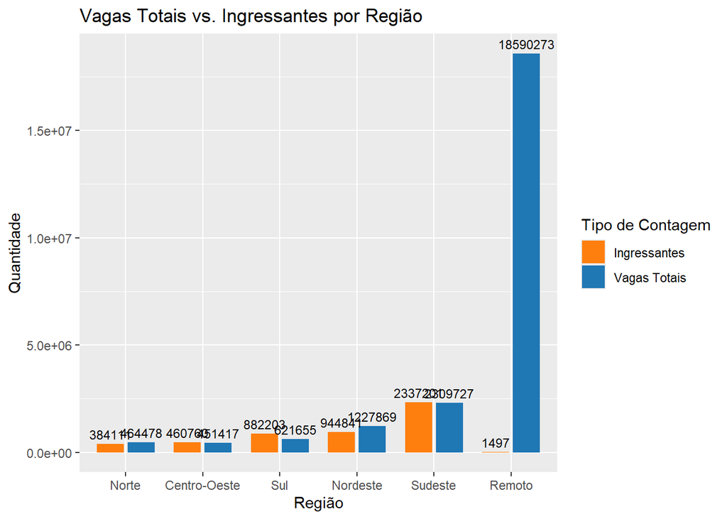

```r
dados_longos <- ord_vagas_regiao %>%
  select(regiao, vagas_total, ingressantes) %>%
  pivot_longer(
    cols = c(vagas_total, ingressantes),
    names_to = "Tipo_de_Contagem",
    values_to = "Quantidade"
  )
ggplot(dados_longos, aes(x = reorder(regiao, Quantidade), y = Quantidade, fill = Tipo_de_Contagem)) +
  geom_bar(stat = "identity", position = position_dodge(width = 0.8), width = 0.7) +
  geom_text(
    aes(label = Quantidade),
    position = position_dodge(width = 0.8),
    vjust = -0.5,
    size = 3
  ) +
  scale_fill_manual(
    values = c("vagas_total" = "#1f77b4", "ingressantes" = "#ff7f0e"),
    labels = c("ingressantes" = "Ingressantes", "vagas_total" = "Vagas Totais")
  ) +
  labs(
    title = "Vagas Totais vs. Ingressantes por Região",
    x = "Região",
    y = "Quantidade",
    fill = "Tipo de Contagem"
  )
```

Observando o gráfico, a discrepancia da quantidade de vagas oferecidas remotamente fica mais evidente.

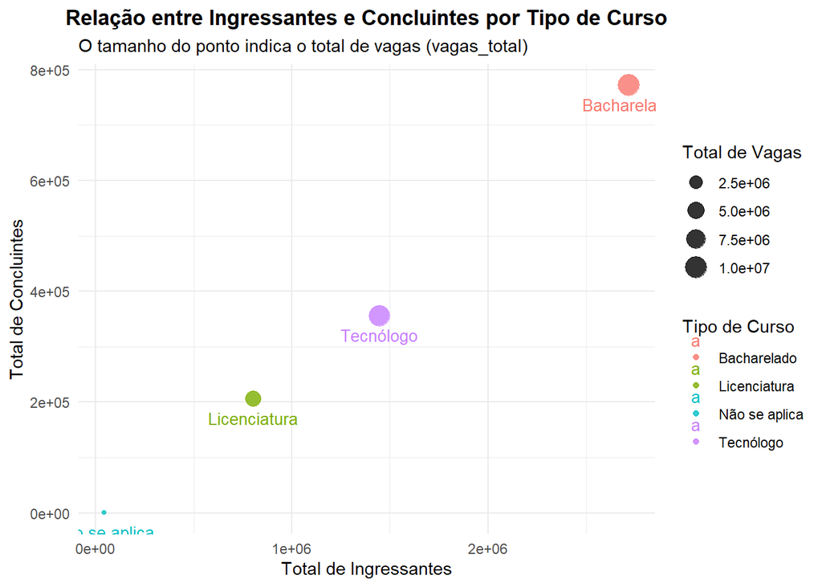

```r
ggplot(vagasA, aes(x = ingressantes, y = concluintes)) +
  geom_point(aes(color = Tipo_de_curso, size = vagas_total), alpha = 0.8) +
  # Adiciona rótulos para identificar cada Tipo_de_curso
  geom_text(aes(label = Tipo_de_curso, color = Tipo_de_curso), vjust = 2, size = 3.5, check_overlap = TRUE) +
  labs(
    title = "Relação entre Ingressantes e Concluintes por Tipo de Curso",
    subtitle = "O tamanho do ponto indica o total de vagas (vagas_total)",
    x = "Total de Ingressantes",
    y = "Total de Concluintes",
    color = "Tipo de Curso",
    size = "Total de Vagas"
  ) +
  theme_minimal() +
  theme(plot.title = element_text(hjust = 0.5, face = "bold"))
```

Outro dado importante de se analisar é o tipo de instituição que está oferecendo os cursos, se é publica ou privada.

```r
concluintes_regiao<- dadosB%>%
  group_by(regiao)%>%
  summarise(
    cln_regiao=sum(nmr_concluintes),
    .groups='drop')

concluinte<- dadosB%>%
  group_by(regiao,tipo_de_inst) %>%
  summarise(
    qnt_concluintes= sum(nmr_concluintes),
  .groups= 'drop')

concluinteB<- concluinte%>%
  left_join(concluintes_regiao, by ="regiao")%>%
  mutate(pct_concluintes = round((qnt_concluintes / cln_regiao) * 100, 2)) %>%
  pivot_wider(
    names_from =tipo_de_inst,
    values_from = c(qnt_concluintes, pct_concluintes))%>%
  arrange(desc(cln_regiao))%>%
    select(-cln_regiao)
print(concluinteB)
```

```
## # A tibble: 6 × 5
##   regiao    qnt_concluintes_Priv…¹ qnt_concluintes_Publ…² pct_concluintes_Priv…³
##   <chr>                      <int>                  <int>                  <dbl>
## 1 Sudeste                   523982                 103021                   83.6
## 2 Nordeste                  195250                  68095                   74.1
## 3 Sul                       192952                  38274                   83.4
## 4 Centro-O…                  91150                  23931                   79.2
## 5 Norte                      73674                  23186                   76.1
## 6 Remoto                       473                      0                  100
## # ℹ abbreviated names: ¹qnt_concluintes_Privada, ²qnt_concluintes_Publica,
## #   ³pct_concluintes_Privada
## # ℹ 1 more variable: pct_concluintes_Publica <dbl>
```

Podemos observar que o quantitativo de formandos das instituições privadas é bem maior.

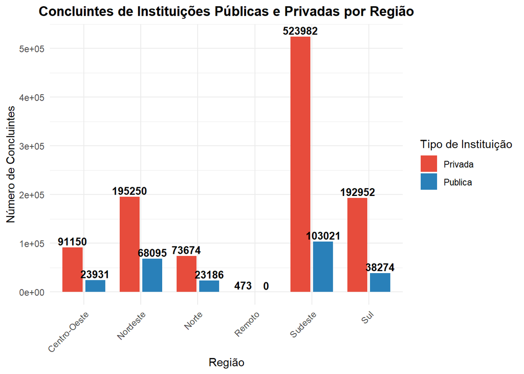

```r
ggplot(concluinte, aes(x = regiao, y = qnt_concluintes, fill = tipo_de_inst)) +
  geom_bar(stat = "identity", position = position_dodge(width = 0.8), width = 0.7) +
  geom_text(
    aes(label = qnt_concluintes),
    position = position_dodge(width = 0.8),
    vjust = -0.3,
    size = 3.5,
    fontface = "bold"
  ) +
  scale_fill_manual(
    values = c("Privada" = "#e74c3c", "Publica" = "#2980b9") # Vermelho/Azul para contraste
  ) +
  labs(
    title = "Concluintes de Instituições Públicas e Privadas por Região",
    x = "Região",
    y = "Número de Concluintes",
    fill = "Tipo de Instituição"
  ) +
  theme_minimal() +
  theme(
    plot.title = element_text(hjust = 0.5, face = "bold"),
    axis.text.x = element_text(angle = 45, hjust = 1)
  )
```